# Part II - (Salaries Dataset)

## by (Michael Afolami)

## Investigation Overview

> My presentation will focus on sharing insights gleaned from the analysis of salary dataset. My key insight for presentation is the effects that any pay an employeee gets apart from their base pay, definitely affects their overall pay. Hence, I will check TotalPayBenefits by year Top ten most common jobs Total Pay vs TotalPayBenefits

## Dataset Overview

> The name of my dataset is Salaries Dataset, and it was obtained from Kaggle. THe dataset contains 148654 observations and 12 variables. As part of my wrangling steps, I dropped a column that contained zero values and had no contribution to the entire dataset. I identified missing numbers and did imputation with the mean. I then moved ahead with the analysis.

## (Visualization 1)

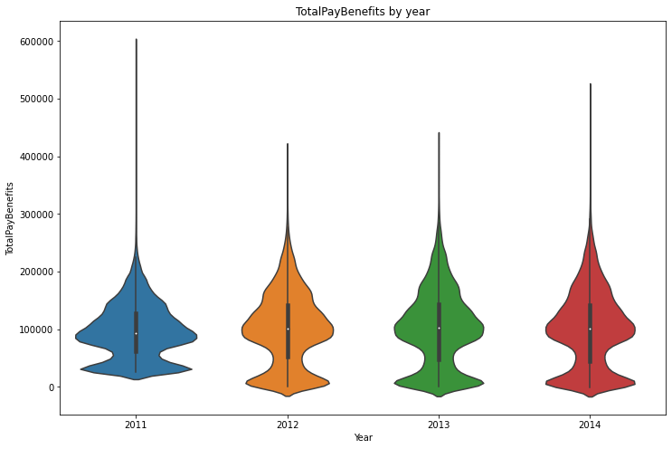

## (Visualization 2)

> There are over 2000 unique jobs in the dataset but the follwoing 10 are the most common jobs

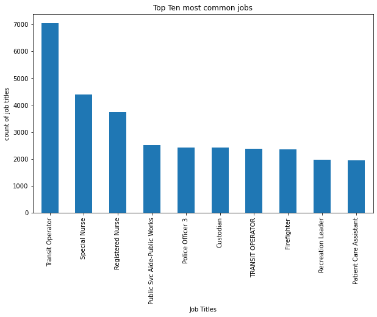

## (Visualization 3)

The chart below shows the relationship between TotalPay and TotalPayBenefits. As expected, the total amount of money earned by an employee correlates positively with the TotalPayBenefits. That is, the higher an employees TotalPay, the higher also is their TotalPayBenefits.

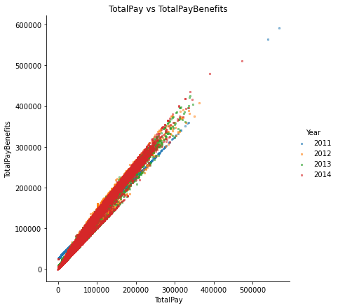